# Kira Plastinina

Katheu

7/9/2021

## Defining the Question

Kira Plastinina is a Russian brand that is sold through a defunct chain of retail stores in Russia, Ukraine, Kazakhstan, Belarus, China, Philippines, and Armenia. The brand’s Sales and Marketing team would like to understand their customer’s behavior from data that they have collected over the past year. More specifically, they would like to learn the characteristics of customer groups.

## Metric of success

To perform clustering stating insights drawn from my analysis and visualizations. Upon implementation, provide comparisons between the approaches i.e. K-Means clustering vs Hierarchical clustering highlighting the strengths and limitations of each approach in the context of my analysis.

## Understanding the Context

Customer behavior analysis is an observation of how customers interact with your website. Studying the customer behavior allows you to answer questions such as how marketing campaigns can be improved to effectively influence the customer’s behavior. There are four types of consumer buying behavior;

- Complex buying behavior
- Dissonance-reducing buying behavior
- Habitual buying behavior
- Varity seeking behavior

## Experimental Design

- Problem Definition
- Data Sourcing
- Check the Data
- Perform Data Cleaning
- Perform Exploratory Data Analysis
- Implement the Solution
- Challenge the Solution
- Follow up Questions

## Data Relevance

- The dataset consists of 10 numerical and 8 categorical attributes. The ‘Revenue’ attribute can be used as the class label.
- “Administrative”, “Administrative Duration”, “Informational”, “Informational Duration”, “Product Related” and “Product Related Duration” represents the number of different types of pages visited by the visitor in that session and total time spent in each of these page categories. The values of these features are derived from the URL information of the pages visited by the user and updated in real-time when a user takes an action, e.g. moving from one page to another.
- The “Bounce Rate”, “Exit Rate” and “Page Value” features represent the metrics measured by “Google Analytics” for each page in the e-commerce site.
- The value of the “Bounce Rate” feature for a web page refers to the percentage of visitors who enter the site from that page and then leave (“bounce”) without triggering any other requests to the analytics server during that session.
- The value of the “Exit Rate” feature for a specific web page is calculated as for all pageviews to the page, the percentage that was the last in the session.
- The “Page Value” feature represents the average value for a web page that a user visited before completing an e-commerce transaction. The “Special Day” feature indicates the closeness of the site visiting time to a specific special day (e.g. Mother’s Day, Valentine’s Day) in which the sessions are more likely to be finalized with the transaction. The value of this attribute is determined by considering the dynamics of e-commerce such as the duration between the order date and delivery date. For example, for Valentina’s day, this value takes a nonzero value between February 2 and February 12, zero before and after this date unless it is close to another special day, and its maximum value of 1 on February 8. The dataset also includes the operating system, browser, region, traffic type, visitor type as returning or new visitor, a Boolean value indicating whether the date of the visit is weekend, and month of the year.

## Loading the Dataset

```r
kira <- read.csv('http://bit.ly/EcommerceCustomersDataset')
```

### Previewing the top of our dataset

```r
head(kira)
```

```
##   Administrative Administrative_Duration Informational Informational_Duration
## 1              0                       0             0                      0
## 2              0                       0             0                      0
## 3              0                      -1             0                     -1
## 4              0                       0             0                      0
## 5              0                       0             0                      0
## 6              0                       0             0                      0
##   ProductRelated ProductRelated_Duration BounceRates ExitRates PageValues
## 1              1                0.000000  0.20000000 0.2000000          0
## 2              2               64.000000  0.00000000 0.1000000          0
## 3              1               -1.000000  0.20000000 0.2000000          0
## 4              2                2.666667  0.05000000 0.1400000          0
## 5             10              627.500000  0.02000000 0.0500000          0
## 6             19              154.216667  0.01578947 0.0245614          0
##   SpecialDay Month OperatingSystems Browser Region TrafficType
## 1          0   Feb                1       1      1           1
## 2          0   Feb                2       2      1           2
## 3          0   Feb                4       1      9           3
## 4          0   Feb                3       2      2           4
## 5          0   Feb                3       3      1           4
## 6          0   Feb                2       2      1           3
##         VisitorType Weekend Revenue
## 1 Returning_Visitor   FALSE   FALSE
## 2 Returning_Visitor   FALSE   FALSE
## 3 Returning_Visitor   FALSE   FALSE
## 4 Returning_Visitor   FALSE   FALSE
## 5 Returning_Visitor    TRUE   FALSE
## 6 Returning_Visitor   FALSE   FALSE
```

### Previewing the bottom of our dataset

```r
tail(kira)
```

```
##       Administrative Administrative_Duration Informational
## 12325              0                       0             1
## 12326              3                     145             0
## 12327              0                       0             0
## 12328              0                       0             0
## 12329              4                      75             0
## 12330              0                       0             0
##       Informational_Duration ProductRelated ProductRelated_Duration BounceRates
## 12325                      0             16                 503.000 0.000000000
## 12326                      0             53                1783.792 0.007142857
## 12327                      0              5                 465.750 0.000000000
## 12328                      0              6                 184.250 0.083333333
## 12329                      0             15                 346.000 0.000000000
## 12330                      0              3                  21.250 0.000000000
##        ExitRates PageValues SpecialDay Month OperatingSystems Browser Region
## 12325 0.03764706    0.00000          0   Nov                2       2      1
## 12326 0.02903061   12.24172          0   Dec                4       6      1
## 12327 0.02133333    0.00000          0   Nov                3       2      1
## 12328 0.08666667    0.00000          0   Nov                3       2      1
## 12329 0.02105263    0.00000          0   Nov                2       2      3
## 12330 0.06666667    0.00000          0   Nov                3       2      1
##       TrafficType       VisitorType Weekend Revenue
## 12325           1 Returning_Visitor   FALSE   FALSE
## 12326           1 Returning_Visitor    TRUE   FALSE
## 12327           8 Returning_Visitor    TRUE   FALSE
## 12328          13 Returning_Visitor    TRUE   FALSE
## 12329          11 Returning_Visitor   FALSE   FALSE
## 12330           2       New_Visitor    TRUE   FALSE
```

## Data Exploration

```r
View(kira)
```

Checking the structure of our dataset.

```r
str(kira)
```

```
## 'data.frame':    12330 obs. of  18 variables:
##  $ Administrative         : int  0 0 0 0 0 0 0 1 0 0 ...
##  $ Administrative_Duration: num  0 0 -1 0 0 0 -1 -1 0 0 ...
##  $ Informational          : int  0 0 0 0 0 0 0 0 0 0 ...
##  $ Informational_Duration : num  0 0 -1 0 0 0 -1 -1 0 0 ...
##  $ ProductRelated         : int  1 2 1 2 10 19 1 1 2 3 ...
##  $ ProductRelated_Duration: num  0 64 -1 2.67 627.5 ...
##  $ BounceRates            : num  0.2 0 0.2 0.05 0.02 ...
##  $ ExitRates              : num  0.2 0.1 0.2 0.14 0.05 ...
##  $ PageValues             : num  0 0 0 0 0 0 0 0 0 0 ...
##  $ SpecialDay             : num  0 0 0 0 0 0 0.4 0 0.8 0.4 ...
##  $ Month                  : chr  "Feb" "Feb" "Feb" "Feb" ...
##  $ OperatingSystems       : int  1 2 4 3 3 2 2 1 2 2 ...
##  $ Browser                : int  1 2 1 2 3 2 4 2 2 4 ...
##  $ Region                 : int  1 1 9 2 1 1 3 1 2 1 ...
##  $ TrafficType            : int  1 2 3 4 4 3 3 5 3 2 ...
##  $ VisitorType            : chr  "Returning_Visitor" "Returning_Visitor" "Returning_Visitor" "Returning_Visitor" ...
##  $ Weekend                : logi  FALSE FALSE FALSE FALSE TRUE FALSE ...
##  $ Revenue                : logi  FALSE FALSE FALSE FALSE FALSE FALSE ...
```

Our dataframe has 12330 rows and 18 columns. 2 of which have a logical data type, 2 have a character data type, 7 are of the integers data type and the other 7 are numerical.

Checking the summary of our dataframe kira.

```r
summary(kira)
```

```
##  Administrative   Administrative_Duration Informational
##  Min.   : 0.000   Min.   :  -1.00         Min.   : 0.000
##  1st Qu.: 0.000   1st Qu.:   0.00         1st Qu.: 0.000
##  Median : 1.000   Median :   8.00         Median : 0.000
##  Mean   : 2.318   Mean   :  80.91         Mean   : 0.504
##  3rd Qu.: 4.000   3rd Qu.:  93.50         3rd Qu.: 0.000
##  Max.   :27.000   Max.   :3398.75         Max.   :24.000
##  NA's   :14       NA's   :14              NA's   :14
##  Informational_Duration ProductRelated   ProductRelated_Duration
##  Min.   :  -1.00        Min.   :  0.00   Min.   :   -1.0
##  1st Qu.:   0.00        1st Qu.:  7.00   1st Qu.:  185.0
##  Median :   0.00        Median : 18.00   Median :  599.8
##  Mean   :  34.51        Mean   : 31.76   Mean   : 1196.0
##  3rd Qu.:   0.00        3rd Qu.: 38.00   3rd Qu.: 1466.5
##  Max.   :2549.38        Max.   :705.00   Max.   :63973.5
##  NA's   :14             NA's   :14       NA's   :14
##   BounceRates         ExitRates         PageValues        SpecialDay
##  Min.   :0.000000   Min.   :0.00000   Min.   :  0.000   Min.   :0.00000
##  1st Qu.:0.000000   1st Qu.:0.01429   1st Qu.:  0.000   1st Qu.:0.00000
##  Median :0.003119   Median :0.02512   Median :  0.000   Median :0.00000
##  Mean   :0.022152   Mean   :0.04300   Mean   :  5.889   Mean   :0.06143
##  3rd Qu.:0.016684   3rd Qu.:0.05000   3rd Qu.:  0.000   3rd Qu.:0.00000
##  Max.   :0.200000   Max.   :0.20000   Max.   :361.764   Max.   :1.00000
##  NA's   :14         NA's   :14
##     Month           OperatingSystems    Browser           Region
##  Length:12330       Min.   :1.000    Min.   : 1.000   Min.   :1.000
##  Class :character   1st Qu.:2.000    1st Qu.: 2.000   1st Qu.:1.000
##  Mode  :character   Median :2.000    Median : 2.000   Median :3.000
##                     Mean   :2.124    Mean   : 2.357   Mean   :3.147
##                     3rd Qu.:3.000    3rd Qu.: 2.000   3rd Qu.:4.000
##                     Max.   :8.000    Max.   :13.000   Max.   :9.000
##
##   TrafficType    VisitorType         Weekend         Revenue
##  Min.   : 1.00   Length:12330       Mode :logical   Mode :logical
##  1st Qu.: 2.00   Class :character   FALSE:9462      FALSE:10422
##  Median : 2.00   Mode  :character   TRUE :2868      TRUE :1908
##  Mean   : 4.07
##  3rd Qu.: 4.00
##  Max.   :20.00
##
```

## Data Cleaning

Finding the total missing values in our dataset.

```r
colSums(is.na(kira))
```

```
##          Administrative Administrative_Duration           Informational
##                      14                      14                      14
##  Informational_Duration          ProductRelated ProductRelated_Duration
##                      14                      14                      14
##             BounceRates               ExitRates              PageValues
##                      14                      14                       0
##              SpecialDay                   Month        OperatingSystems
##                       0                       0                       0
##                 Browser                  Region             TrafficType
##                       0                       0                       0
##             VisitorType                 Weekend                 Revenue
##                       0                       0                       0
```

```r
sum(is.na(kira))
```

```
## [1] 112
```

There are 112 missing values in total. We will drop these.

```r
kira <- na.omit(kira)
```

```r
library(na.tools)
anyNA(kira)
```

```
## [1] FALSE
```

Checking for duplicated rows.

```r
kira[duplicated(kira),]
```

```
##       Administrative Administrative_Duration Informational
## 159                0                       0             0
## 179                0                       0             0
## 419                0                       0             0
## 457                0                       0             0
## 484                0                       0             0
## 513                0                       0             0
## 555                0                       0             0
## 590                0                       0             0
## 660                0                       0             0
## 775                0                       0             0
## 873                0                       0             0
## 890                0                       0             0
## 923                0                       0             0
## 948                0                       0             0
```

[output cut: 457 more lines]

There are 117 duplicated rows in this dataset. We shall drop these so as to achieve better results.

```r
kira_p <- kira[!duplicated(kira), ]
```

Confirming the duplicated rows have been dropped.

```r
kira_p[duplicated(kira_p),]
```

```
##  [1] Administrative          Administrative_Duration Informational
##  [4] Informational_Duration  ProductRelated          ProductRelated_Duration
##  [7] BounceRates             ExitRates               PageValues
## [10] SpecialDay              Month                   OperatingSystems
## [13] Browser                 Region                  TrafficType
## [16] VisitorType             Weekend                 Revenue
## <0 rows> (or 0-length row.names)
```

Let’s fix the structure of this dataset

```r
kira_p$Revenue <- gsub(FALSE, 0, kira_p$Revenue)
kira_p$Revenue <- gsub(TRUE, 1, kira_p$Revenue)
kira_p$Weekend <- gsub(TRUE, 1, kira_p$Weekend)
kira_p$Weekend <- gsub(FALSE, 0, kira_p$Weekend)
```

```r
kira_p$Month <- factor(kira_p$Month, levels = c("Feb", "Mar", "May", "June", "Jul", "Aug", "Sep", "Oct", "Nov", "Dec"), ordered = TRUE)
kira_p$OperatingSystems <- factor(kira_p$OperatingSystems)
kira_p$Browser <- factor(kira_p$Browser)
kira_p$Region <- factor(kira_p$Region)
kira_p$TrafficType <- factor(kira_p$TrafficType)
kira_p$VisitorType <- factor(kira_p$VisitorType)
kira_p$Revenue <- factor(kira_p$Revenue)
kira_p$Weekend <- factor(kira_p$Weekend)
```

Confirming the structure is okay to work with.

```r
str(kira_p)
```

```
## 'data.frame':    12199 obs. of  18 variables:
##  $ Administrative         : int  0 0 0 0 0 0 0 1 0 0 ...
##  $ Administrative_Duration: num  0 0 -1 0 0 0 -1 -1 0 0 ...
##  $ Informational          : int  0 0 0 0 0 0 0 0 0 0 ...
##  $ Informational_Duration : num  0 0 -1 0 0 0 -1 -1 0 0 ...
##  $ ProductRelated         : int  1 2 1 2 10 19 1 1 2 3 ...
##  $ ProductRelated_Duration: num  0 64 -1 2.67 627.5 ...
##  $ BounceRates            : num  0.2 0 0.2 0.05 0.02 ...
##  $ ExitRates              : num  0.2 0.1 0.2 0.14 0.05 ...
##  $ PageValues             : num  0 0 0 0 0 0 0 0 0 0 ...
##  $ SpecialDay             : num  0 0 0 0 0 0 0.4 0 0.8 0.4 ...
##  $ Month                  : Ord.factor w/ 10 levels "Feb"<"Mar"<"May"<..: 1 1 1 1 1 1 1 1 1 1 ...
##  $ OperatingSystems       : Factor w/ 8 levels "1","2","3","4",..: 1 2 4 3 3 2 2 1 2 2 ...
##  $ Browser                : Factor w/ 13 levels "1","2","3","4",..: 1 2 1 2 3 2 4 2 2 4 ...
##  $ Region                 : Factor w/ 9 levels "1","2","3","4",..: 1 1 9 2 1 1 3 1 2 1 ...
##  $ TrafficType            : Factor w/ 20 levels "1","2","3","4",..: 1 2 3 4 4 3 3 5 3 2 ...
##  $ VisitorType            : Factor w/ 3 levels "New_Visitor",..: 3 3 3 3 3 3 3 3 3 3 ...
##  $ Weekend                : Factor w/ 2 levels "0","1": 1 1 1 1 2 1 1 2 1 1 ...
##  $ Revenue                : Factor w/ 2 levels "0","1": 1 1 1 1 1 1 1 1 1 1 ...
##  - attr(*, "na.action")= 'omit' Named int [1:14] 1066 1133 1134 1135 1136 1137 1474 1475 1476 1477 ...
##   ..- attr(*, "names")= chr [1:14] "1066" "1133" "1134" "1135" ...
```

Checking for outliers

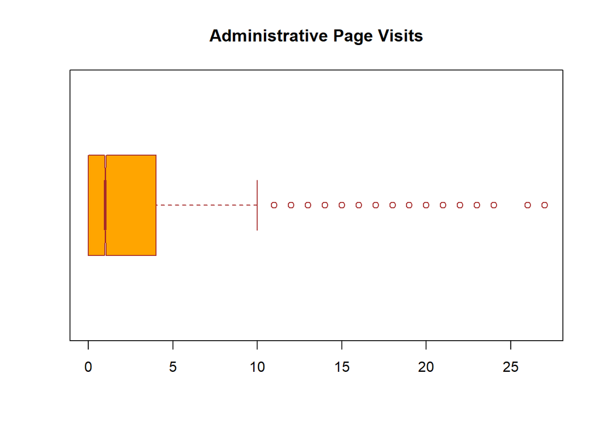

```r
boxplot(kira_p$Administrative,
        main ="Administrative Page Visits",
        col = "orange",
        border  = 'brown',
        horizontal = TRUE,
        notch = TRUE)
```

```r
#There are some outliers in the administrative column.
```

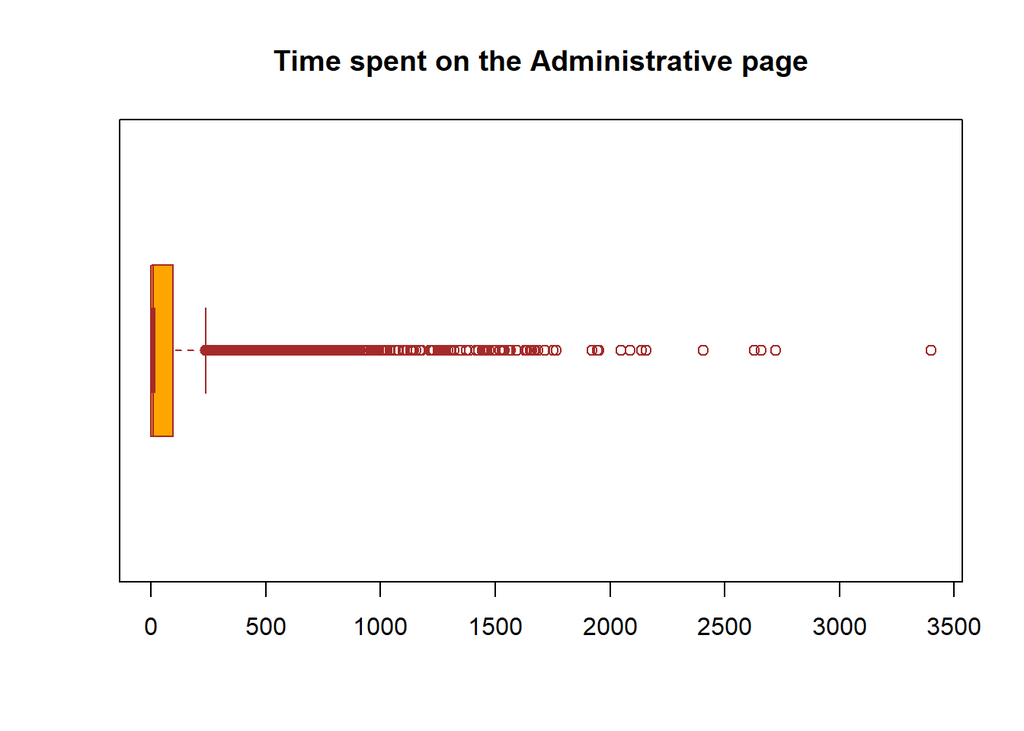

```r
boxplot(kira_p$Administrative_Duration,
        main ="Time spent on the Administrative page",
        col = "orange",
        border  = 'brown',
        horizontal = TRUE,
        notch = TRUE)
```

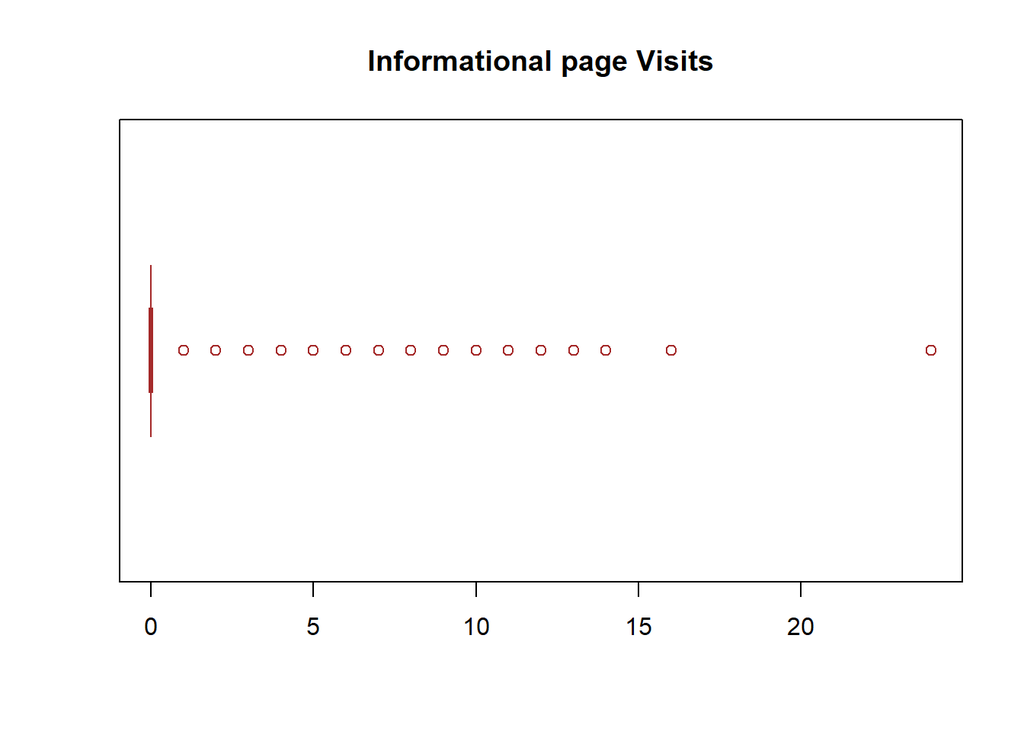

```r
boxplot(kira_p$Informational,
        main ="Informational page Visits",
        col = "orange",
        border  = 'brown',
        horizontal = TRUE,
        notch = TRUE)
```

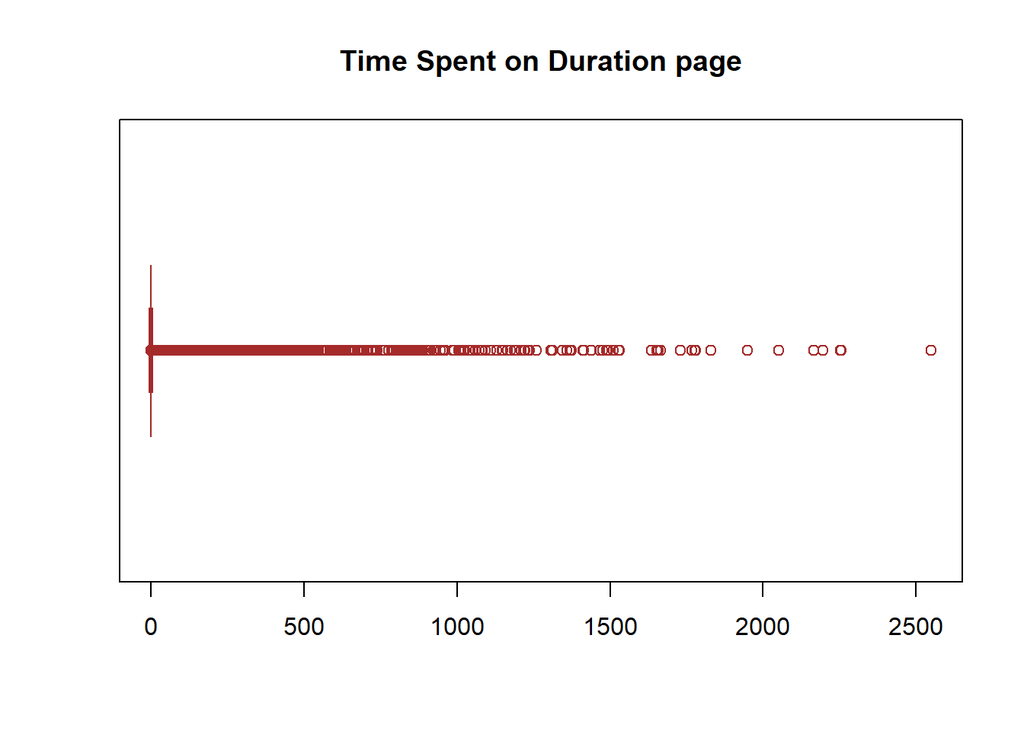

```r
boxplot(kira_p$Informational_Duration,
        main ="Time Spent on Duration page",
        col = "orange",
        border  = 'brown',
        horizontal = TRUE,
        notch = TRUE)
```

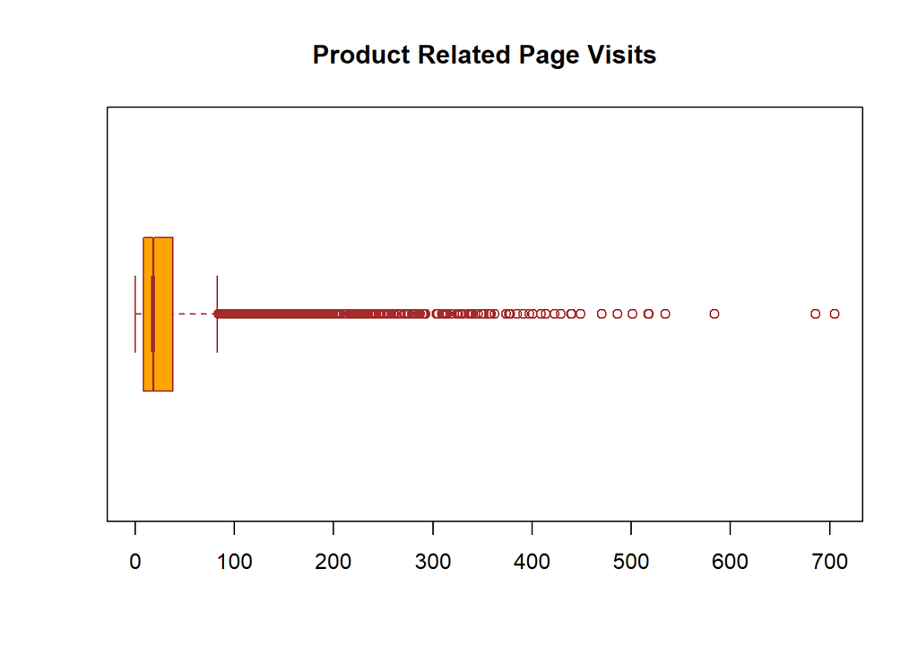

```r
boxplot(kira_p$ProductRelated,
        main ="Product Related Page Visits",
        col = "orange",
        border  = 'brown',
        horizontal = TRUE,
        notch = TRUE)
```

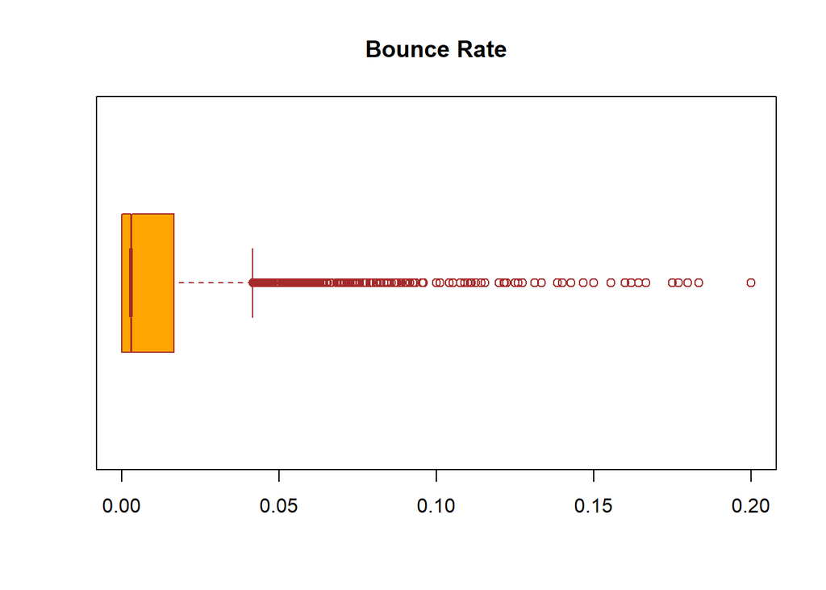

```r
boxplot(kira_p$BounceRates,
        main ="Bounce Rate",
        col = "orange",
        border  = 'brown',
        horizontal = TRUE,
        notch = TRUE)
```

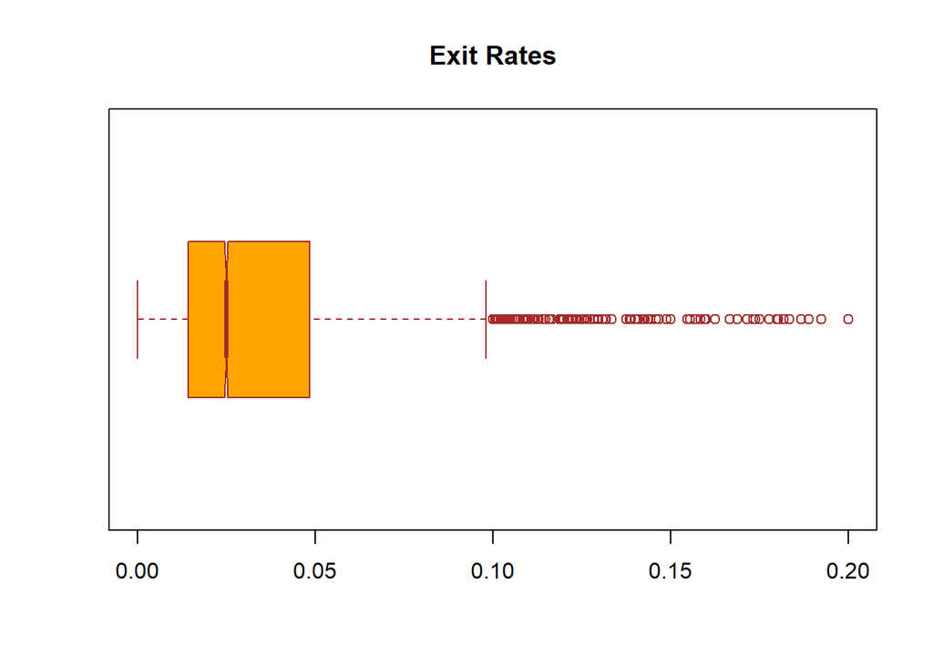

```r
boxplot(kira_p$ExitRates,
        main ="Exit Rates",
        col = "orange",
        border  = 'brown',
        horizontal = TRUE,
        notch = TRUE)
```

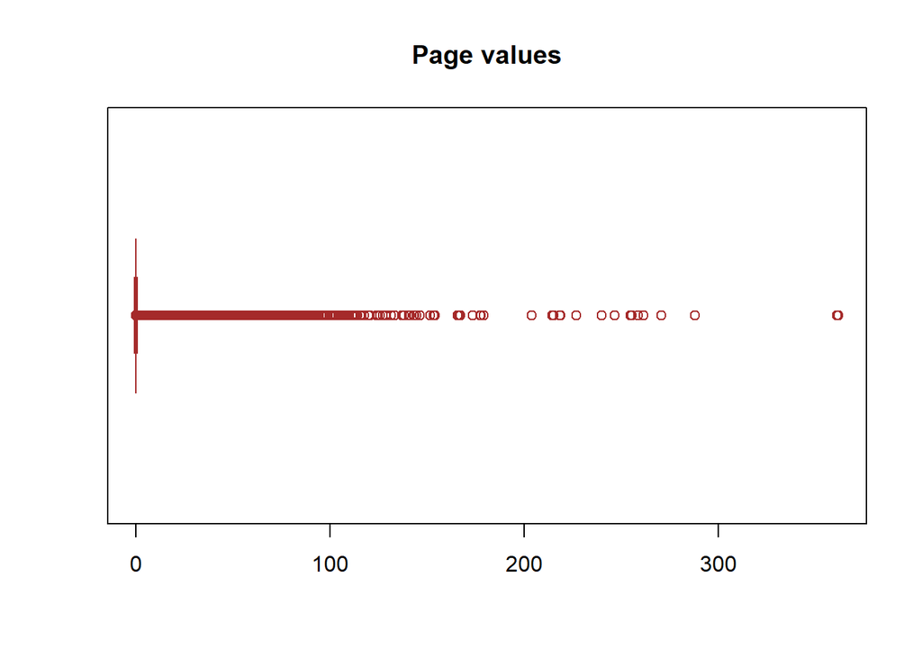

```r
boxplot(kira_p$PageValues,
        main ="Page values",
        col = "orange",
        border  = 'brown',
        horizontal = TRUE,
        notch = TRUE)
```

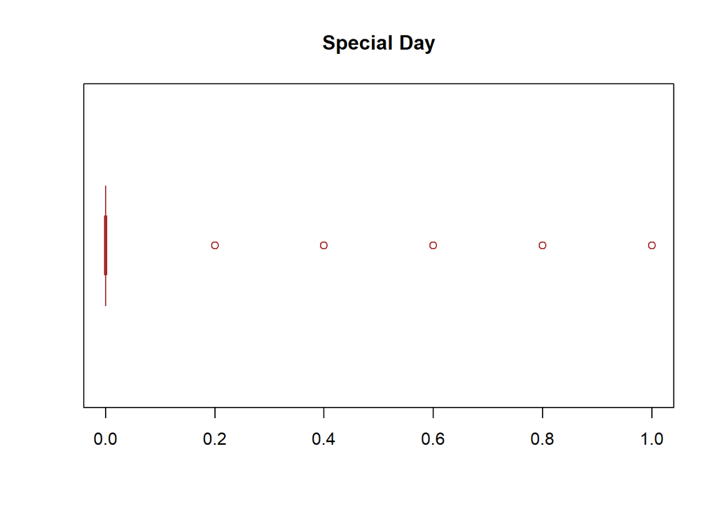

```r
boxplot(kira_p$SpecialDay,
        main ="Special Day",
        col = "orange",
        border  = 'brown',
        horizontal = TRUE,
        notch = TRUE)
```

## Exploratory Data Analysis

### Univariate Analysis

#### Meaasures of Central Tendency

Finding the mean of our numeric columns

```r
colMeans(kira_p[sapply(kira_p,is.numeric)])
```

```
##          Administrative Administrative_Duration           Informational
##            2.340028e+00            8.168214e+01            5.088122e-01
##  Informational_Duration          ProductRelated ProductRelated_Duration
##            3.483734e+01            3.205845e+01            1.207508e+03
##             BounceRates               ExitRates              PageValues
##            2.044674e-02            4.149678e-02            5.952500e+00
##              SpecialDay
##            6.197229e-02
```

Finding the median of our numeric columns.

```r
admin_median <- median(kira_p$Administrative)
admin_time <- median(kira_p$Administrative_Duration)
info_median <- median(kira_p$Informational)
info_time <- median(kira_p$Informational_Duration)
product_median <- median(kira_p$ProductRelated)
product_time <- median(kira_p$ProductRelated_Duration)
bounce_median <- median(kira_p$BounceRates)
exit_median <- median(kira_p$ExitRates)
page_median <- median(kira_p$PageValues)
specialday_median <- median(kira_p$SpecialDay)

admin_median
```

```
## [1] 1
```

```r
admin_time
```

```
## [1] 9
```

```r
info_median
```

```
## [1] 0
```

```r
info_time
```

```
## [1] 0
```

```r
product_median
```

```
## [1] 18
```

```r
product_time
```

```
## [1] 609.5417
```

```r
bounce_median
```

```
## [1] 0.002930403
```

```r
exit_median
```

```
## [1] 0.025
```

```r
page_median
```

```
## [1] 0
```

```r
specialday_median
```

```
## [1] 0
```

Finding the mode of our numeric columns. Creating the mode function.

```r
getmode <- function(v) {
   uniqv <- unique(v)
   uniqv[which.max(tabulate(match(v, uniqv)))]}
```

```r
getmode(kira_p$Administrative)
```

```
## [1] 0
```

```r
getmode(kira_p$Administrative_Duration)
```

```
## [1] 0
```

```r
getmode(kira_p$Informational)
```

```
## [1] 0
```

```r
getmode(kira_p$Informational_Duration)
```

```
## [1] 0
```

```r
getmode(kira_p$ProductRelated)
```

```
## [1] 1
```

```r
getmode(kira_p$ProductRelated_Duration)
```

```
## [1] 0
```

```r
getmode(kira_p$BounceRates)
```

```
## [1] 0
```

```r
getmode(kira_p$ExitRates)
```

```
## [1] 0.2
```

```r
getmode(kira_p$PageValues)
```

```
## [1] 0
```

```r
getmode(kira_p$SpecialDay)
```

```
## [1] 0
```

Finding the range in our columns. The results will give us the minimum and maximum values in our numeric columns.

```r
range(kira_p$Administrative)
```

```
## [1]  0 27
```

```r
range(kira_p$Administrative_Duration)
```

```
## [1]   -1.00 3398.75
```

```r
range(kira_p$Informational)
```

```
## [1]  0 24
```

```r
range(kira_p$Informational_Duration)
```

```
## [1]   -1.000 2549.375
```

```r
range(kira_p$ProductRelated)
```

```
## [1]   0 705
```

```r
range(kira_p$ProductRelated_Duration)
```

```
## [1]    -1.00 63973.52
```

```r
range(kira_p$BounceRates)
```

```
## [1] 0.0 0.2
```

```r
range(kira_p$ExitRates)
```

```
## [1] 0.0 0.2
```

```r
range(kira_p$PageValues)
```

```
## [1]   0.0000 361.7637
```

```r
range(kira_p$SpecialDay)
```

```
## [1] 0 1
```

Getting the Quantiles in our numeric columns.

```r
quantile(kira_p$Administrative)
```

```
##   0%  25%  50%  75% 100%
##    0    0    1    4   27
```

```r
quantile(kira_p$Administrative_Duration)
```

```
##      0%     25%     50%     75%    100%
##   -1.00    0.00    9.00   94.75 3398.75
```

```r
quantile(kira_p$Informational)
```

```
##   0%  25%  50%  75% 100%
##    0    0    0    0   24
```

```r
quantile(kira_p$Informational_Duration)
```

```
##       0%      25%      50%      75%     100%
##   -1.000    0.000    0.000    0.000 2549.375
```

```r
quantile(kira_p$ProductRelated)
```

```
##   0%  25%  50%  75% 100%
##    0    8   18   38  705
```

```r
quantile(kira_p$ProductRelated_Duration)
```

```
##         0%        25%        50%        75%       100%
##    -1.0000   193.5833   609.5417  1477.5648 63973.5222
```

```r
quantile(kira_p$BounceRates)
```

```
##          0%         25%         50%         75%        100%
## 0.000000000 0.000000000 0.002930403 0.016666667 0.200000000
```

```r
quantile(kira_p$ExitRates)
```

```
##         0%        25%        50%        75%       100%
## 0.00000000 0.01422258 0.02500000 0.04848485 0.20000000
```

```r
quantile(kira_p$PageValues)
```

```
##       0%      25%      50%      75%     100%
##   0.0000   0.0000   0.0000   0.0000 361.7637
```

```r
quantile(kira_p$SpecialDay)
```

```
##   0%  25%  50%  75% 100%
##    0    0    0    0    1
```

Finding the variance of the numeric columns. This shows how the data values are dispersed around the mean.

```r
var(kira_p$Administrative)
```

```
## [1] 11.09457
```

```r
var(kira_p$Administrative_Duration)
```

```
## [1] 31516.25
```

```r
var(kira_p$Informational)
```

```
## [1] 1.62771
```

```r
var(kira_p$Informational_Duration)
```

```
## [1] 20010.51
```

```r
var(kira_p$ProductRelated)
```

```
## [1] 1989.241
```

```r
var(kira_p$ProductRelated_Duration)
```

```
## [1] 3686121
```

```r
var(kira_p$BounceRates)
```

```
## [1] 0.002061387
```

```r
var(kira_p$ExitRates)
```

```
## [1] 0.0021388
```

```r
var(kira_p$PageValues)
```

```
## [1] 348.1132
```

```r
var(kira_p$SpecialDay)
```

```
## [1] 0.03988432
```

Finding the standard deviation of our numeric columns

```r
sd(kira_p$Administrative)
```

```
## [1] 3.330851
```

```r
sd(kira_p$Administrative_Duration)
```

```
## [1] 177.5282
```

```r
sd(kira_p$Informational)
```

```
## [1] 1.275817
```

```r
sd(kira_p$Informational_Duration)
```

```
## [1] 141.4585
```

```r
sd(kira_p$ProductRelated)
```

```
## [1] 44.60091
```

```r
sd(kira_p$ProductRelated_Duration)
```

```
## [1] 1919.927
```

```r
sd(kira_p$BounceRates)
```

```
## [1] 0.0454025
```

```r
sd(kira_p$ExitRates)
```

```
## [1] 0.04624716
```

```r
sd(kira_p$PageValues)
```

```
## [1] 18.65779
```

```r
sd(kira_p$SpecialDay)
```

```
## [1] 0.1997106
```

#### Descriptive Analysis

```r
table(kira_p$Revenue)
```

```
##
##     0     1
## 10291  1908
```

```r
table(kira_p$Weekend)
```

```
##
##    0    1
## 9343 2856
```

```r
table(kira_p$VisitorType)
```

```
##
##       New_Visitor             Other Returning_Visitor
##              1693                81             10425
```

```r
table(kira_p$TrafficType)
```

```
##
##    1    2    3    4    5    6    7    8    9   10   11   12   13   14   15   16
## 2383 3907 2017 1066  260  443   40  343   41  450  247    1  728   13   36    3
##   17   18   19   20
##    1   10   17  193
```

```r
table(kira_p$Region)
```

```
##
##    1    2    3    4    5    6    7    8    9
## 4711 1127 2382 1168  317  800  758  431  505
```

```r
table(kira_p$Browser)
```

```
##
##    1    2    3    4    5    6    7    8    9   10   11   12   13
## 2426 7878  105  730  466  174   49  135    1  163    6   10   56
```

```r
table(kira_p$OperatingSystems)
```

```
##
##    1    2    3    4    5    6    7    8
## 2548 6536 2530  478    6   19    7   75
```

```r
table(kira_p$Month)
```

```
##
##  Feb  Mar  May June  Jul  Aug  Sep  Oct  Nov  Dec
##  182 1853 3328  285  432  433  448  549 2983 1706
```

#### Histograms

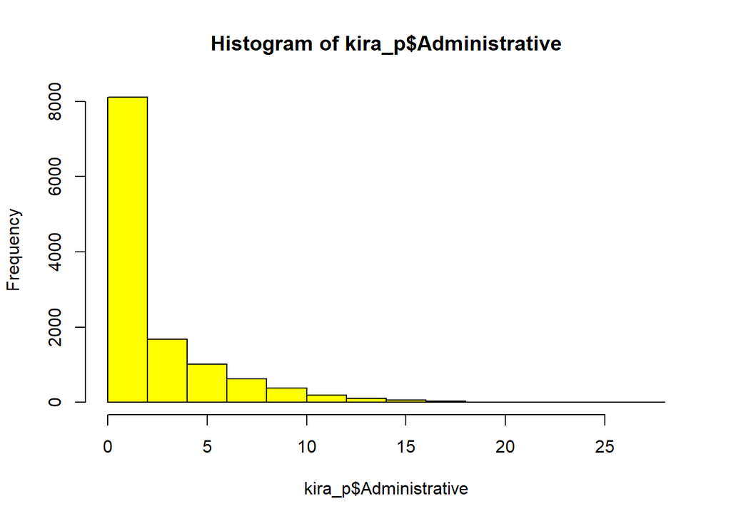

```r
hist(kira_p$Administrative, col  = "yellow")
```

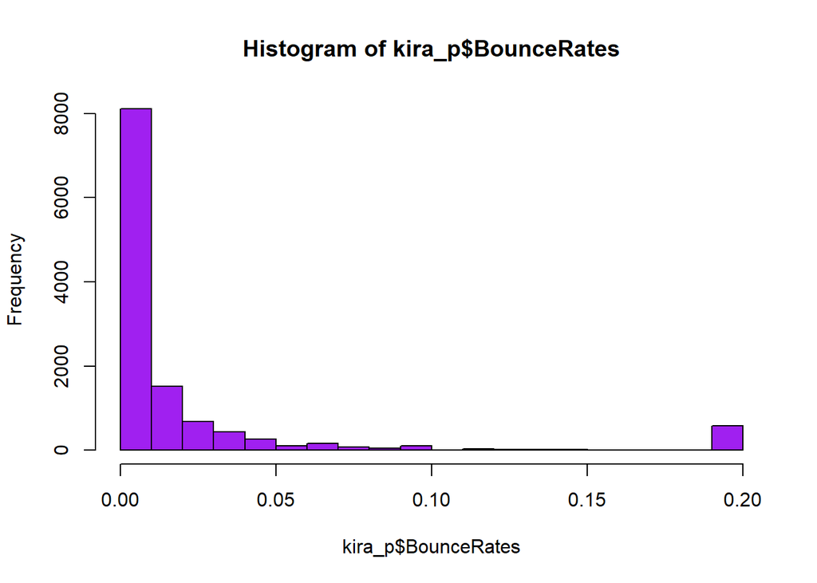

```r
hist(kira_p$BounceRates, col  = "purple")
```

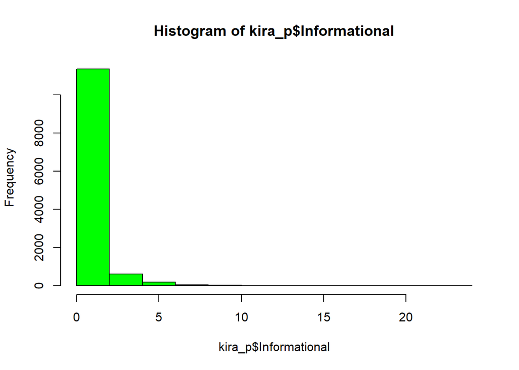

```r
hist(kira_p$Informational, col  = "green")
```

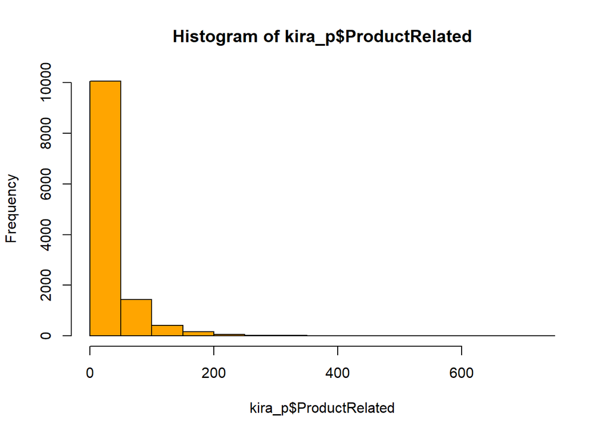

```r
hist(kira_p$ProductRelated, col  = "orange")
```

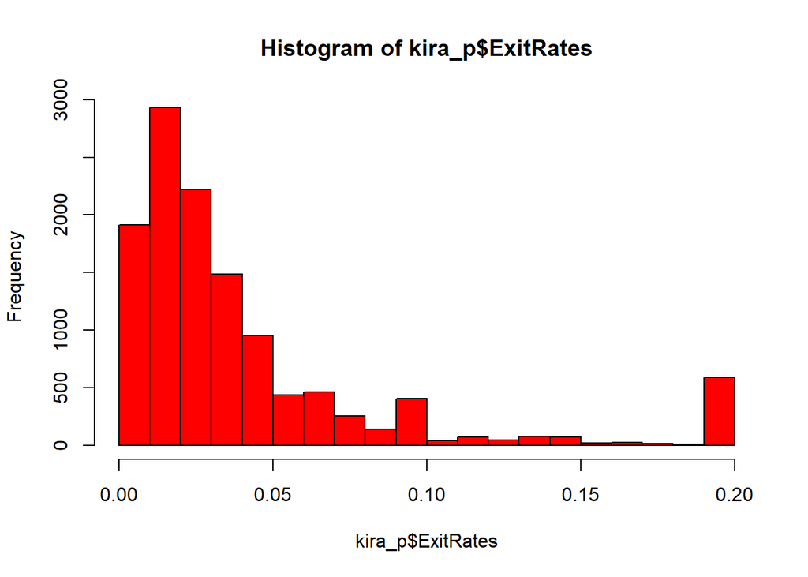

```r
hist(kira_p$ExitRates, col  = "red")
```

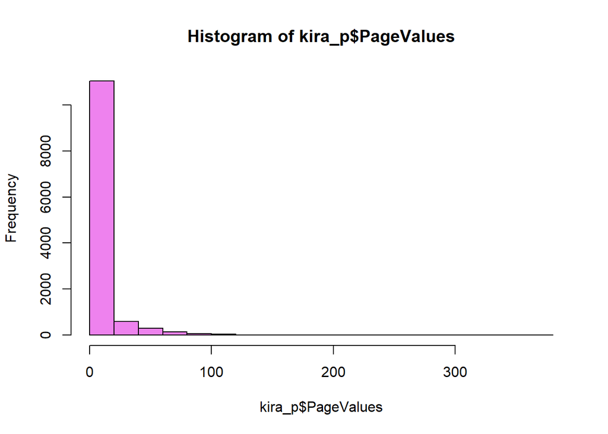

```r
hist(kira_p$PageValues, col  = "violet")
```

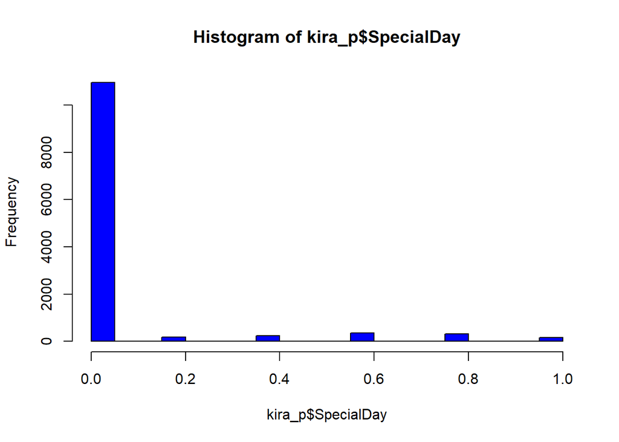

```r
hist(kira_p$SpecialDay, col  = "blue")
```